# QTM 150 Project: How is the used car market behaving ?

Pierre

05/12/2018

## Introduction

[figure not shown]

In this project, we are going to take a closer look at the used car market. I always wondered how some cars could see their value rising so quickly while having more than 30/40 years. I remember having a lot of discussions with my father on which car would be the next rising star of the classic car market. Therefore, I’m going to study the evolution of prices in this market and try to understand which factors influence the market.

—2nd Dataset: `hist_cars` is a data frame recording the market value of 4 different cars since 2006. These 4 cars are collection cars that have different market trajectories: 1986 Audi GT, 1986 Renault R5 Turbo 1, 1987 Ferrari 328 GTS, and 1977 Porsche 911 Carrera Turbo. These data have been found on the website Hagerty.

—3rd Dataset: `autos` is a data frame gathering several characteristics of used cars. This data will allow us to class car according to their gearbox, power(Hp), mileage, year, category, and damage suffered.

Thanks to this Datasets, I’m going to try to answer to different questions:

- Which are the cars that are more likely to see their value increases in the future?
- When is the best time to buy used cars cost-efficiently speaking ?
- Which factors influence the used car market price ?

## Datasets

First, we import our datasets.

`data` will correspond to the dataset `true_car_listings`:

```r
#Please check your email to download the datasets. email adress: louis.pierre.battesti@emory.edu
data <- read.csv("true_car_listings.csv")
```

`data2` will correspond to the dataset `autos`.

```r
data2 <- read.csv("autos.csv")
```

Then, We create a new dataframe named `hist_cars`:

```r
hist_cars <- data.frame(
  Year = c(1986,2006,2007,2008,2009,2010,2011,2012,2013,2014,2015,2016,2017,2018,1977,2006,2007,2008,2009,2010,2011,2012,2013,2014,2015,2016,2017,2018,1987,2006,2007,2008,2009,2010,2011,2012,2013,2014,2015,2016,2017,2018,1986,2006,2007,2008,2009,2010,2011,2012,2013,2014,2015,2016,2017,2018),
  Model = c("1986 Renault R5 Turbo 1","1986 Renault R5 Turbo 1","1986 Renault R5 Turbo 1","1986 Renault R5 Turbo 1","1986 Renault R5 Turbo 1","1986 Renault R5 Turbo 1","1986 Renault R5 Turbo 1","1986 Renault R5 Turbo 1","1986 Renault R5 Turbo 1","1986 Renault R5 Turbo 1","1986 Renault R5 Turbo 1","1986 Renault R5 Turbo 1","1986 Renault R5 Turbo 1","1986 Renault R5 Turbo 1","1977 Porsche 911 Carrera Turbo","1977 Porsche 911 Carrera Turbo","1977 Porsche 911 Carrera Turbo","1977 Porsche 911 Carrera Turbo","1977 Porsche 911 Carrera Turbo","1977 Porsche 911 Carrera Turbo","1977 Porsche 911 Carrera Turbo","1977 Porsche 911 Carrera Turbo","1977 Porsche 911 Carrera Turbo","1977 Porsche 911 Carrera Turbo","1977 Porsche 911 Carrera Turbo","1977 Porsche 911 Carrera Turbo","1977 Porsche 911 Carrera Turbo","1977 Porsche 911 Carrera Turbo","1987 Ferrari 328 GTS","1987 Ferrari 328 GTS","1987 Ferrari 328 GTS","1987 Ferrari 328 GTS","1987 Ferrari 328 GTS","1987 Ferrari 328 GTS","1987 Ferrari 328 GTS","1987 Ferrari 328 GTS","1987 Ferrari 328 GTS","1987 Ferrari 328 GTS","1987 Ferrari 328 GTS","1987 Ferrari 328 GTS","1987 Ferrari 328 GTS","1987 Ferrari 328 GTS","1986 Audi GT","1986 Audi GT","1986 Audi GT","1986 Audi GT","1986 Audi GT","1986 Audi GT","1986 Audi GT","1986 Audi GT","1986 Audi GT","1986 Audi GT","1986 Audi GT","1986 Audi GT","1986 Audi GT","1986 Audi GT"),
  Price = c(17255,25000,25000,25000,32000,37600,37600,37600,38600,38600,40200,87800,97800,99500,40000,28000, 35000,42000,41200,41600,44500,45000,60600,124000,228000,212000,206000,184000,34000,23400, 25000,31000,30300,31000,30500,33000,42000,49000,58300,64400,54000,51900,12000,3900,4200,5640,6300,6400,6800,6800,6800,7100,7100,7100,7700,7800)
)
```

## Which are the cars that are more likely to see their value increases in the future?

Using the dataset `hist_cars`, we are going to study the behavior of 4 differents cars that are the 1986 Audi GT, 1986 Renault R5 Turbo 1, 1987 Ferrari 328 GTS, and 1977 Porsche 911 Carrera Turbo in order to try to highlight any comon points between these 4 vehicles. Here is the market evolution since their production year :

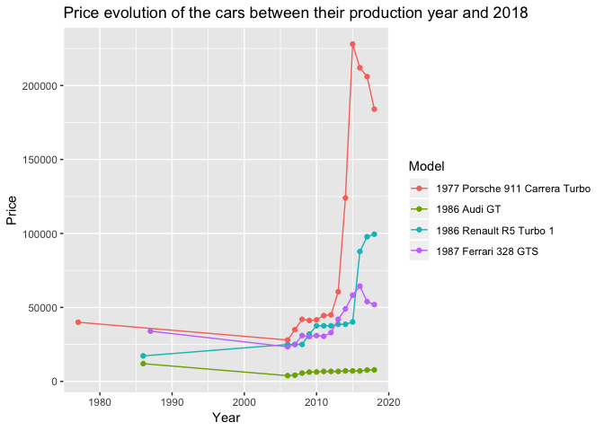

Now that we have a clear idea of the evolution of the price of these models, let’s see their behavior in the future.

For the `1977 Porsche 911 Carrera Turbo`:

```r
evol_price_P911 <- hist_cars %>%
  filter(Model == "1977 Porsche 911 Carrera Turbo") %>%
  group_by(Year)
lm(Price ~ Year, data = evol_price_P911)
```

```
##
## Call:
## lm(formula = Price ~ Year, data = evol_price_P911)
##
## Coefficients:
## (Intercept)         Year
##    -7735823         3897
```

```r
predict(lm(Price ~ Year, data = evol_price_P911))
```

```
##         1         2         3         4         5         6         7
## -31515.76  81496.32  85393.29  89290.26  93187.23  97084.20 100981.17
##         8         9        10        11        12        13        14
## 104878.14 108775.10 112672.07 116569.04 120466.01 124362.98 128259.95
```

For the `1986 Audi GT`:

```r
evol_price_AGT <- hist_cars %>%
  filter(Model == "1986 Audi GT") %>%
  group_by(Year)
lm(Price ~ Year, data = evol_price_AGT)
```

```
##
## Call:
## lm(formula = Price ~ Year, data = evol_price_AGT)
##
## Coefficients:
## (Intercept)         Year
##    214974.1       -103.5
```

```r
predict(lm(Price ~ Year, data = evol_price_AGT))
```

```
##        1        2        3        4        5        6        7        8
## 9331.330 7260.406 7156.860 7053.313 6949.767 6846.221 6742.675 6639.128
##        9       10       11       12       13       14
## 6535.582 6432.036 6328.490 6224.944 6121.397 6017.851
```

For the `1986 Renault R5 Turbo 1`:

```r
evol_price_R5 <- hist_cars %>%
  filter(Model == "1986 Renault R5 Turbo 1") %>%
  group_by(Year)
lm(Price ~ Year, data = evol_price_R5)
```

```
##
## Call:
## lm(formula = Price ~ Year, data = evol_price_R5)
##
## Coefficients:
## (Intercept)         Year
##    -4494660         2259
```

```r
predict(lm(Price ~ Year, data = evol_price_R5))
```

```
##         1         2         3         4         5         6         7
## -8849.369 36324.960 38583.677 40842.393 43101.110 45359.826 47618.543
##         8         9        10        11        12        13        14
## 49877.259 52135.976 54394.692 56653.409 58912.125 61170.842 63429.558
```

For the `1987 Ferrari 328 GTS`:

```r
evol_price_F328 <- hist_cars %>%
  filter(Model == "1987 Ferrari 328 GTS") %>%
  group_by(Year)
lm(Price ~ Year, data = evol_price_F328)
```

```
##
## Call:
## lm(formula = Price ~ Year, data = evol_price_F328)
##
## Coefficients:
## (Intercept)         Year
##  -1877592.3        953.8
```

```r
predict(lm(Price ~ Year, data = evol_price_F328))
```

```
##        1        2        3        4        5        6        7        8
## 17700.00 35823.08 36776.92 37730.77 38684.62 39638.46 40592.31 41546.15
##        9       10       11       12       13       14
## 42500.00 43453.85 44407.69 45361.54 46315.38 47269.23
```

Thanks to the function ‘lm’ we are able to get the linear model of the price’s evolution. This function will allow us to predict the future trends of these cars’ markets. This approximation should be able to lead us to a more concrete understanding of which car’s value increases and why.

Here is the graph showing how should the price of each car behave in the next 20 years, using the formula :

$$YearCoefficient * year - InterceptCoefficient$$

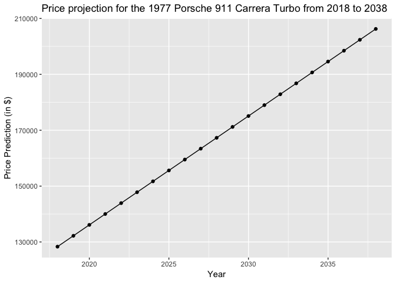

```r
new_year= c(2018:2038)
data1 <- data.frame(
  new_year,
  Price_predict = 3897*new_year-7735823
  )

ggplot(data1,aes(x=data1$new_year,y=data1$Price_predict)) +
  geom_point()+
  geom_line()+
  labs(x="Year",y="Price Prediction (in $)", title = "Price projection for the 1977 Porsche 911 Carrera Turbo from 2018 to 2038")
```

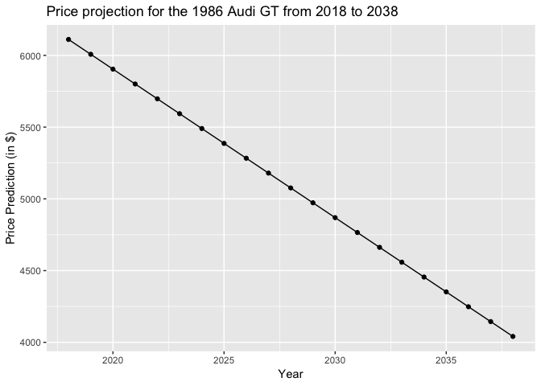

```r
data5 <- data.frame(
  new_year,
  Price_predict = (-103.5)*new_year+214974.1
)
ggplot(data5,aes(x=data5$new_year,y=data5$Price_predict)) +
  geom_point()+
  geom_line()+
  labs(x="Year",y="Price Prediction (in $)", title = "Price projection for the 1986 Audi GT from 2018 to 2038")
```

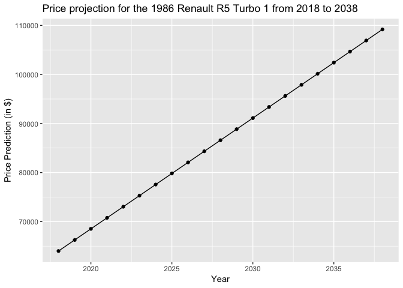

```r
data3 <- data.frame(
  new_year,
  Price_predict = 2259*new_year-4494660
)
ggplot(data3,aes(x=data3$new_year,y=data3$Price_predict)) +
  geom_point()+
  geom_line()+
  labs(x="Year",y="Price Prediction (in $)", title = "Price projection for the 1986 Renault R5 Turbo 1 from 2018 to 2038")
```

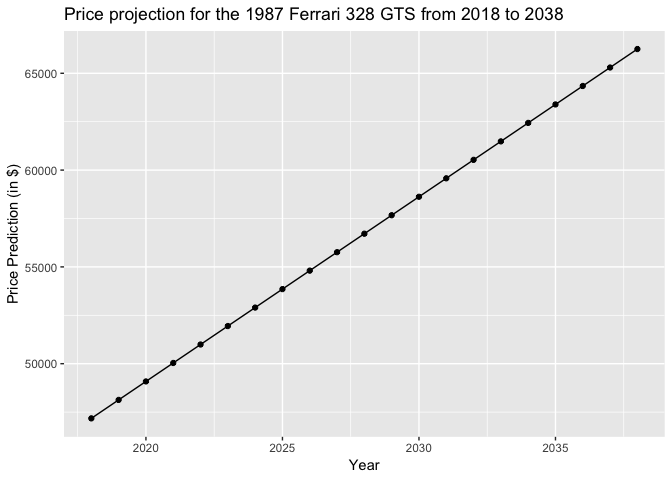

```r
data4 <- data.frame(
  new_year,
  Price_predict = 953.8*new_year-1877592.3
)
ggplot(data4,aes(x=data4$new_year,y=data4$Price_predict)) +
  geom_point()+
  geom_line()+
  labs(x="Year",y="Price Prediction (in $)", title = "Price projection for the 1987 Ferrari 328 GTS from 2018 to 2038")
```

```r
data4
```

```
##    new_year Price_predict
## 1      2018       47176.1
## 2      2019       48129.9
## 3      2020       49083.7
## 4      2021       50037.5
## 5      2022       50991.3
## 6      2023       51945.1
## 7      2024       52898.9
## 8      2025       53852.7
## 9      2026       54806.5
## 10     2027       55760.3
## 11     2028       56714.1
## 12     2029       57667.9
## 13     2030       58621.7
## 14     2031       59575.5
## 15     2032       60529.3
## 16     2033       61483.1
## 17     2034       62436.9
## 18     2035       63390.7
## 19     2036       64344.5
## 20     2037       65298.3
## 21     2038       66252.1
```

[figure not shown]

1977 Porsche 911 Carrera Turbo

[figure not shown]

1986 Audi GT

— For the `1986 Renault R5 Turbo 1` we can notice an increase of 170% in the next 20 years.

[figure not shown]

— For the `1987 Ferrari 328 GTS` we can notice an increase of 140% in the next 20 years.

[figure not shown]

1987 Ferrari 328 GTS

According to these estimations, the best investisment would we the `1986 Renault R5 Turbo 1`. This car’s value will see an increase of approximately 170% in the next 20 years. This is due mainly to its scarcity and to the palmares of the car. This car has competed in the WRC(World Rallye Championship) and won many titles which makes it a colletor car for many lovers of this sport. Moreover, this extreme sportcar has only been produced 1690 times conversely to the `1986 Audi GT` more than 40000 times.

## When is the best time to buy used cars cost-efficiently speaking ?

In order to determine the cost efficiency, we first need to take into account the mileage value which is a determinant factor in the price of the cars. We know that when the mileage of a car increases the price decreases. In order to avoid this parameter, we are only going to take into account the cars with a mileage less than 30000 miles in order to consider the cars of the dataset in a well-preserved state.

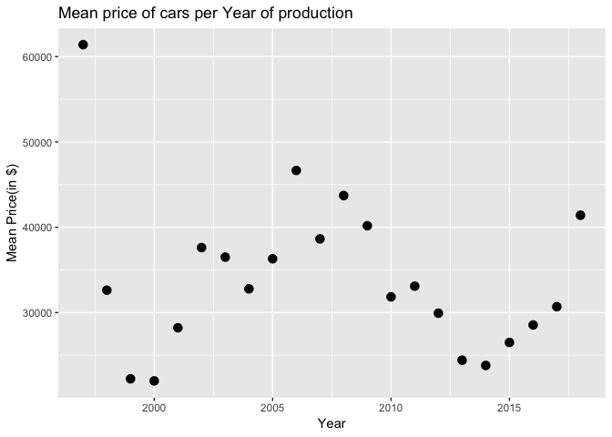

```r
ggplot(g1,aes(x=Year,y=mean_year))+
  geom_point(size=3)+
  labs(x="Year",y="Mean Price(in $)", title = "Mean price of cars per Year of production")
```

Year with the best compromise cost-efficiency speaking : Year : 2000

We can conclude from this result that the best time to buy a car is 18 years after its production.

## Which factors influence the used car market price ?

Here is our 3rd dataset `autos.csv` that gathers cars prices along with their caracteristics which will help us understand which of those are influencing the price.

```r
exp_data2 <- data2 %>%
  select(price,vehicleType,yearOfRegistration,gearbox,powerPS,brand,model,notRepairedDamage,kilometer) %>%
  filter(price >= 500 & price <= 1000000) %>%
  filter(powerPS >= 50 & powerPS <= 1500) %>%
  filter(notRepairedDamage == "ja" | notRepairedDamage == "nein") %>%
  filter(gearbox == "manuell" | gearbox== "automatik") %>%
  filter(vehicleType == "cabrio"|vehicleType == "coupe"|vehicleType == "limousine"|vehicleType== "suv")

names(exp_data2) <- c("Price", "VehiculeCategory", "YearOfRegistration", "Gearbox", "Hp", "Make", "Model", "Damage", "Mileage")
levels(exp_data2$VehiculeCategory) <- c("NA", "andere","bus", "Convertible", "Coupe", "kleinwagen", "Kombi","Sedan","SUV")
levels(exp_data2$Gearbox) <- c("NA", "Automatic", "Manual")
levels(exp_data2$Damage) <- c("NA", "Yes", "No")

exp_data2$PriceRange <- NA
if (exp_data2$Price  <= 10000) {
  exp_data2$PriceRange = "Low Price"
} else if (exp_data2$Price > 10000 & exp_data2$Price <=30000) {
  exp_data2$PriceRange = "Affordable"
} else {
  exp_data2$PriceRange="High"
}

exp_data2$MileRange <- NA
if (exp_data2$Mileage  <= 20000) {
  exp_data2$MileRange = "0-20000 miles"
} else if (exp_data2$Mileage > 20000 & exp_data2$Mileage <=100000) {
  exp_data2$MileRange = "20000-100000 miles"
} else {
  exp_data2$MileRange="+100000 miles"
}

summary(exp_data2)
```

```
##      Price           VehiculeCategory YearOfRegistration      Gearbox
##  Min.   :   500   Sedan      :37582   Min.   :1934       NA       :    0
##  1st Qu.:  2285   Convertible: 9489   1st Qu.:1999       Automatic:18577
##  Median :  5500   Coupe      : 7328   Median :2004       Manual   :41992
##  Mean   :  9144   SUV        : 6170   Mean   :2003
##  3rd Qu.: 11900   NA         :    0   3rd Qu.:2008
##  Max.   :999999   andere     :    0   Max.   :2017
##                   (Other)    :    0
##        Hp                    Make            Model       Damage
##  Min.   :  50.0   bmw          :11675   golf    : 7396   NA :    0
##  1st Qu.: 105.0   volkswagen   :10843   3er     : 5587   Yes: 4807
##  Median : 140.0   mercedes_benz: 8964   andere  : 5209   No :55762
##  Mean   : 153.9   audi         : 6784   astra   : 2221
##  3rd Qu.: 179.0   opel         : 4139   c_klasse: 2085
##  Max.   :1500.0   ford         : 2307   5er     : 2044
##                   (Other)      :15857   (Other) :36027
##     Mileage        PriceRange         MileRange
##  Min.   :  5000   Length:60569       Length:60569
##  1st Qu.:100000   Class :character   Class :character
##  Median :150000   Mode  :character   Mode  :character
##  Mean   :121817
##  3rd Qu.:150000
##  Max.   :150000
##
```

Now let’s evaluate each of these variables:

#### Price VS Vehicle’s Category

Let’s compare each vehicule’s categories and see how they affect the price:

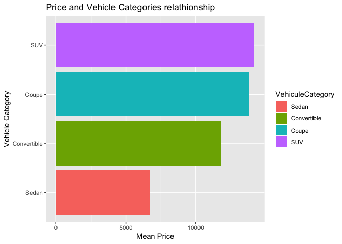

```r
graphp <- exp_data2 %>%
  group_by(VehiculeCategory) %>%
  summarise(
    meanPrice=mean(Price, na.rm=T)
  )

graphp %>%
  mutate(VehiculeCategory = fct_reorder(VehiculeCategory, meanPrice)) %>%
  ggplot( aes(x=VehiculeCategory, y=meanPrice, fill = VehiculeCategory)) +
    geom_bar(stat="identity") +
    labs(y="Mean Price", x= "Vehicle Category", title = "Price and Vehicle Categories relathionship") +
    coord_flip()
```

According to the graph the most expensive category is the `SUV` while the `Sedan` cars are way cheaper than others.

#### Price VS Gearbox

Now let’s compare how the Gearbox type influences the price:

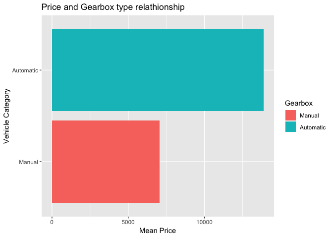

```r
graph1 <- exp_data2 %>%
  group_by(Gearbox) %>%
  summarise(
    meanPrice=mean(Price, na.rm=T)
  )

graph1 %>%
  mutate(Gearbox = fct_reorder(Gearbox, meanPrice)) %>%
  ggplot( aes(x=Gearbox, y=meanPrice, fill = Gearbox)) +
    geom_bar(stat="identity") +
    labs(y="Mean Price", x= "Vehicle Category", title = "Price and Gearbox type relathionship") +
    coord_flip()
```

Not surprisingly the `Manual` models are less expensive than `Automatic` ones.

#### Price VS HP

How does the power of the car influence the price ?

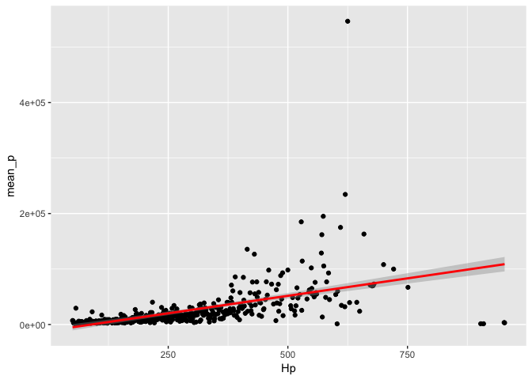

```r
graph3 <- exp_data2 %>%
  group_by(Hp)%>%
  filter( Hp < 1000) %>%
  summarise(
    mean_p = mean(Price, na.rm=T)
  )

ggplot(graph3,aes(x=Hp,y=mean_p)) +
  geom_point() +
  geom_smooth(method="lm", size=1, color="red")
```

According to the graph, the more the Hp the car has, the more the car is expensive.

## Conclusion

Used car market is a very complex subject because it involves a lot of different factors to set the price of a car. However thanks to this project we will be able to have a more accurate vision of how the prices fluctuate and what factors are responsible for that.

We saw that scarcity and car’s history can play an important part in the first part of our study case, while showing that the best time to buy a used car is 18 after its production in a second time. Finally, we have seen the influence of different factors like the engine power(Hp), the vehicule category, and the gearbox type.

However, the used car market can also be influenced by more complex factors such as the current economy situation of a country, people’s opinion, or the history of the car. For example, if a car is seen in a famous movie, it can make its value highly increase. This is why the used car market can sometimes be inpredictible. Nevertheless, some cars have always been promised to an incredible increase of their price like the Mclaren F1 or the Lancia Stratos Stradale.

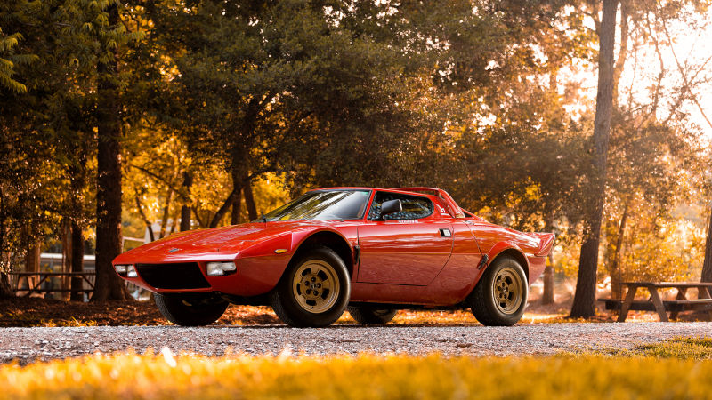

Lancia Stratos HF Stradale

[figure not shown]

Mclaren F1

## Ressources

Ressources used for this project :

- https://www.kaggle.com/jpayne/852k-used-car-listings#true_car_listings.csv
- https://www.kaggle.com/orgesleka/used-cars-database
- https://www.r-graph-gallery.com
- https://www.hagerty.com/apps/valuationtools/search/auto
- https://www.rdocumentation.org/packages/stats/versions/3.5.1/topics/predict.lm
- https://rmarkdown.rstudio.com/lesson-6.html
- https://www.earthdatascience.org/courses/earth-analytics/document-your-science/add-images-to-rmarkdown-report/
- https://cran.r-project.org/web/packages/prettydoc/vignettes/architect.html